# Getting started with bagelR

# Overview

`bagelR` is an R package with a C++ backend that performs fast Bayesian online changepoint detection for linear models. It implements the algorithm in [Bagel: A Fast Bayesian Online Changepoint Detection Algorithm for Linear Models via Posterior Merging](https://arxiv.org/html/2611.03230v1). The algorithm extends classical Bayesian online changepoint detection to linear models and introduces a merging strategy to reduce the cost of posterior updating while maintaining an approximation to the posterior distribution. A short video introduces the general idea of Bagel through an application to Azure LLM trace data.

[figure not shown]

The video shows the online setting, while the package supports both offline and online use: data arrive sequentially in the online setting, whereas all data are available in the offline setting. This vignette first introduces the model interface through offline examples of changes in mean, slope, and seasonality, including a mean change with autocorrelated errors. It then uses a mean change to illustrate the online setting. In both settings, `bagelR` processes observations sequentially and considers at most one change per detector run. Models that can be expressed as linear Gaussian models with the conjugate priors described below can be implemented with `bagelR`.

# Installation

The vignette uses the v1.8.2 version.

```r
install.packages("remotes", repos = "https://cloud.r-project.org")

remotes::install_github(
  "grosed/bagel",
  subdir = "bagelR",
  ref = "v1.8.2",
  force = TRUE
)
```

```r
library(bagelR)

n_obs <- 200
tau_true <- 100
```

Suppose the observations follow a linear model with independent Gaussian errors:

$$y_t=a_t^{\mathsf T}\beta+b_{t,\tau}^{\mathsf T}\gamma+\varepsilon_t,
\qquad \varepsilon_t\mid\sigma_\varepsilon^2\overset{\mathrm{iid}}\sim N(0,\sigma_\varepsilon^2),$$

where $\beta$ contains the no-change coefficients and $\gamma$ contains the change coefficients. The vectors $a_t$ and $b_{t,\tau}$ are the corresponding features, with $b_{t,\tau}=0$ for $t\leq\tau$. A change at `tau = k` means the change starts at observation `k + 1`; `tau = 0` is the package’s label for no change. The change term is omitted under the no-change model.

For a change candidate, the coefficient prior is
$$\theta=\left[\beta^{\mathsf T},\,\gamma^{\mathsf T}\right]^{\mathsf T},\qquad
\theta\mid\sigma_\varepsilon^2,\tau\sim N(\mu_\tau,\sigma_\varepsilon^2\Sigma_\tau).$$
Thus, `prior(t)$sigma` is the covariance factor $\Sigma_\tau$; the coefficient covariance is $\sigma_\varepsilon^2\Sigma_\tau$, even when the noise variance is known. When the noise variance is unknown, $\sigma_\varepsilon^2\sim\operatorname{IG}(\nu,\iota)$, with shape $\nu$ and scale $\iota$.

Our aim is to detect whether there is a change by tracking $1-P(\tau=0\mid y_{1:t})$ at each time step, and, if so, where it is by estimating the posterior distribution of the change location $P(\tau\mid y_{1:t})$.

# Model interface

To compute the posterior probabilities for the no-change and change models, we need to specify:

[output not shown]

The detector has three functions as follows. `exact` refers to the total-variation distance used to choose merges in the scalar case; the `approximate` methods use a KL-based bound for this distance.

| Function | Scenario | Noise arguments |
| --- | --- | --- |
| `bagel_kv_exact()` | Known variance, one-dimensional no-change model, e.g. mean change. | `sigma`: known noise standard deviation $\sigma_\varepsilon$. |
| `bagel_kv_approximate()` | Known variance, no-change dimension at least two. | `sigma`: known noise standard deviation $\sigma_\varepsilon$. |
| `bagel_uv_approximate()` | Unknown variance. | `nu`, `iota`: shape and scale of $\sigma_\varepsilon^2\sim\operatorname{IG}(\nu,\iota)$. |

The fitted result provides the following accessors:

[output not shown]

Here $T$ is the stopping time in the online setting or the total number of observations in the offline setting.

# Example - change in mean

The mean change model can be expressed as
$$y_t=\beta+\gamma\mathbf{1}(t>\tau)+\varepsilon_t.$$
In this example, we specify the feature vector, prior, and transformation as follows:
$$h_t(0)=\left[1\right],\qquad
h_t(\tau)=\left[1,\,\mathbf{1}(t>\tau)\right]^{\mathsf T}
\quad(\tau\geq1).$$
$$\mu=\left[0,\,0\right]^{\mathsf T},\quad
\Sigma=\left[\begin{matrix}1&-1\\-1&2\end{matrix}\right],\quad
A_\tau=\left[\begin{matrix}1&1\end{matrix}\right].$$
We use noise standard deviation $\sigma_\varepsilon=1$ if it is known, or $\nu=3,\ \iota=2$ for the inverse-gamma prior when it is unknown.

This prior gives independent pre- and post-change means conditional on the observation variance. The transformation returns the post-change mean $\beta+\gamma$.

```r
feature_mean <- function(t, tau) {
  if (tau == 0) return(matrix(1, 1, 1))
  matrix(c(1, as.numeric(t > tau)), ncol = 1)
}

prior_mean <- function(t) {
  if (t == 1) {
    return(list(mu = matrix(0, 1, 1), sigma = matrix(1, 1, 1)))
  }
  list(mu = matrix(0, 2, 1), sigma = matrix(c(1, -1, -1, 2), 2, 2))
}

transform_mean <- function(tau) {
  if (tau == 0) return(matrix(1, 1, 1))
  matrix(c(1, 1), nrow = 1)
}

set.seed(0)
y_mean <- c(rep(0, tau_true), rep(1, n_obs - tau_true)) + rnorm(n_obs, sd = 1)
```

We fit the mean-change model with known and unknown variance using `bagel_kv_exact()` and `bagel_uv_approximate()`, respectively.

```r
fit_mean_kv <- bagel_kv_exact(
  Y = y_mean, feature_vector = feature_mean, prior = prior_mean,
  transform = transform_mean, p0 = 0.9, p = 1, sigma = 1,
  max_particles = 30, threshold = Inf
)

fit_mean_uv <- bagel_uv_approximate(
  Y = y_mean, feature_vector = feature_mean, prior = prior_mean,
  transform = transform_mean, p0 = 0.9, p = 1, nu = 3, iota = 2,
  max_particles = 30, threshold = Inf
)
```

The plots below show the probability of a change over time and the posterior distribution of the changepoint location when `threshold = Inf`. The red dashed lines mark the MAP locations. The printed outputs show the endpoints and coefficient posterior parameters of the merged group with the largest active weight.

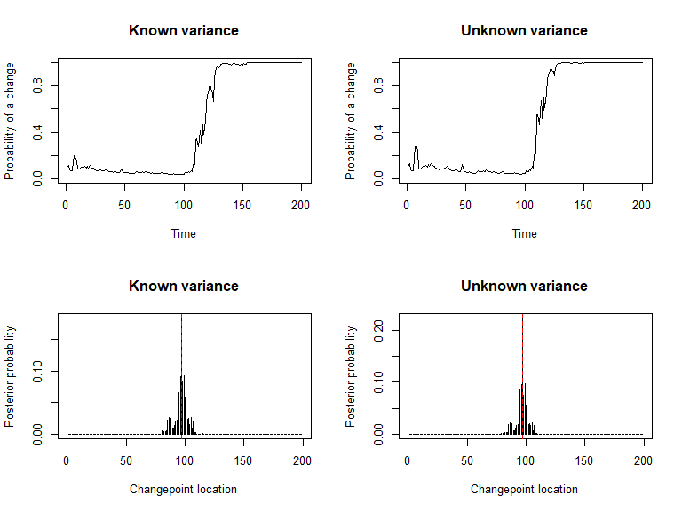

```r
map_mean_kv <- changepoint(fit_mean_kv)$location
map_mean_uv <- changepoint(fit_mean_uv)$location
stoppingtime_mean_kv <- changepoint(fit_mean_kv)$detected
stoppingtime_mean_uv <- changepoint(fit_mean_uv)$detected

par(mfrow = c(2, 2))

plot(1 - weights_tau_zero(fit_mean_kv), type = "l", ylim = c(0, 1),
     xlab = "Time", ylab = "Probability of a change",
     main = "Known variance", col = "black")

plot(1 - weights_tau_zero(fit_mean_uv), type = "l", ylim = c(0, 1),
     xlab = "Time", ylab = "Probability of a change",
     main = "Unknown variance", col = "black")

plot(seq_along(weights(fit_mean_kv)) - 1, weights(fit_mean_kv),
     type = "h", xlab = "Changepoint location",
     ylab = "Posterior probability", main = "Known variance", col = "black")
abline(v = map_mean_kv, col = "red", lty = 2, lwd = 1.5)

plot(seq_along(weights(fit_mean_uv)) - 1, weights(fit_mean_uv),
     type = "h", xlab = "Changepoint location",
     ylab = "Posterior probability", main = "Unknown variance", col = "black")
abline(v = map_mean_uv, col = "red", lty = 2, lwd = 1.5)
```

```r
group <- which.max(active_weights(fit_mean_kv))
right <- taus(fit_mean_kv)[group]
left <- right - length(ratios(fit_mean_kv)[[group]]) + 1
print("Known variance: the most probable merged group is:")
[1] "Known variance: the most probable merged group is:"
print(c(left = left, right = right))
 left right
   97    97
print("They share the same estimated coefficients:")
[1] "They share the same estimated coefficients:"
print(active_posteriors(fit_mean_kv)[[group]])
$tau
[1] 97

$weight
[1] 0.1841626

$mu
             [,1]
[1,] -0.004231703
[2,]  0.947754743

$sigma
            [,1]        [,2]
[1,]  0.01020408 -0.01020408
[2,] -0.01020408  0.01981947
group <- which.max(active_weights(fit_mean_uv))
right <- taus(fit_mean_uv)[group]
left <- right - length(ratios(fit_mean_uv)[[group]]) + 1
print("Unknown variance: the most probable merged group is:")
[1] "Unknown variance: the most probable merged group is:"
print(c(left = left, right = right))
 left right
   97    97
print("They share the same estimated coefficients:")
[1] "They share the same estimated coefficients:"
print(active_posteriors(fit_mean_uv)[[group]])
$tau
[1] 97

$weight
[1] 0.2238019

$mu
             [,1]
[1,] -0.004231703
[2,]  0.947754743

$sigma
            [,1]        [,2]
[1,]  0.01020408 -0.01020408
[2,] -0.01020408  0.01981947

$nu
[1] 103

$iota
[1] 85.98751
```

# Example - change in slope

There are two types of slope changes: continuous and discontinuous. We show examples of both types below, using $x_t=t$.

## Continuous slope change

The observations follow

$$y_t=\beta_0+\beta_1x_t+
(\gamma_0+\gamma_1x_t)\mathbf{1}(t>\tau)+\varepsilon_t,
\qquad \gamma_0=-x_\tau\gamma_1.$$

Define the feature vector as
$$h_t(0)=\left[1,\,x_t\right]^{\mathsf T},\qquad
h_t(\tau)=\left[1,\,x_t,\,\mathbf{1}(t>\tau),\,x_t\mathbf{1}(t>\tau)\right]^{\mathsf T}\quad(\tau\geq1),$$
and the prior and transformation functions as
$$\mu=\left[0,\,0.2,\,0,\,0\right]^{\mathsf T},\qquad
\Sigma_\tau=\left[\begin{matrix}1&0&0&0\\
0&1&0&0\\
0&0&4x_\tau^2&-4x_\tau\\
0&0&-4x_\tau&4\end{matrix}\right],\qquad
A_\tau=\left[\begin{matrix}1&0&1&0\\0&1&0&1\end{matrix}\right].$$
Use $\sigma_\varepsilon=1$ when known, or $\nu=3,\ \iota=2$ for the inverse-gamma prior when unknown.

The covariance is singular to enforce the continuity constraint $\gamma_0+x_\tau\gamma_1=0$.

```r
feature_slope_cont <- function(t, tau) {
  x <- t
  if (tau == 0) return(matrix(c(1, x), ncol = 1))
  matrix(c(1, x, as.numeric(t > tau) * c(1, x)), ncol = 1)
}

prior_slope_cont <- function(t) {
  if (t == 1) {
    return(list(mu = matrix(c(0, 0.2), ncol = 1), sigma = diag(2)))
  }
  x_tau <- t - 1
  covariance <- matrix(0, 4, 4)
  covariance[1:2, 1:2] <- diag(2)
  covariance[3:4, 3:4] <- 4 * matrix(c(x_tau^2, -x_tau, -x_tau, 1), 2, 2)
  list(mu = matrix(c(0, 0.2, 0, 0), ncol = 1), sigma = covariance)
}

transform_slope_cont <- function(tau) {
  if (tau == 0) return(diag(2))
  rbind(c(1, 0, 1, 0), c(0, 1, 0, 1))
}

set.seed(0)
x_cont <- seq_len(n_obs)
y_slope_cont <- 0.2 * x_cont + 2 * pmax(x_cont - tau_true, 0) +
  rnorm(length(x_cont), sd = 1)
```

```r
fit_slope_cont_kv <- bagel_kv_approximate(
  Y = y_slope_cont, feature_vector = feature_slope_cont, prior = prior_slope_cont,
  transform = transform_slope_cont, p0 = 0.9, p = 1, sigma = 1,
  max_particles = 30, threshold = Inf
)

fit_slope_cont_uv <- bagel_uv_approximate(
  Y = y_slope_cont, feature_vector = feature_slope_cont, prior = prior_slope_cont,
  transform = transform_slope_cont, p0 = 0.9, p = 1, nu = 3, iota = 2,
  max_particles = 30, threshold = Inf
)
```

As in the mean-change example, the following plots and outputs summarise the fitted continuous slope-change model.

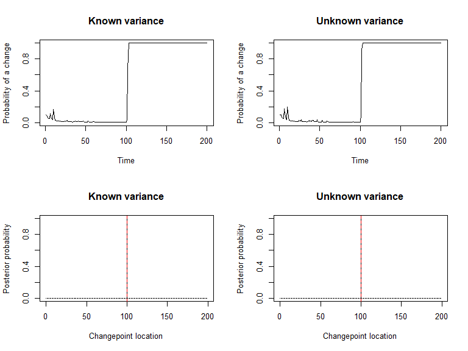

```r
map_slope_cont_kv <- changepoint(fit_slope_cont_kv)$location
map_slope_cont_uv <- changepoint(fit_slope_cont_uv)$location
stoppingtime_slope_cont_kv <- changepoint(fit_slope_cont_kv)$detected
stoppingtime_slope_cont_uv <- changepoint(fit_slope_cont_uv)$detected

par(mfrow = c(2, 2))

plot(1 - weights_tau_zero(fit_slope_cont_kv), type = "l", ylim = c(0, 1),
     xlab = "Time", ylab = "Probability of a change",
     main = "Known variance", col = "black")

plot(1 - weights_tau_zero(fit_slope_cont_uv), type = "l", ylim = c(0, 1),
     xlab = "Time", ylab = "Probability of a change",
     main = "Unknown variance", col = "black")

plot(seq_along(weights(fit_slope_cont_kv)) - 1, weights(fit_slope_cont_kv),
     type = "h", xlab = "Changepoint location",
     ylab = "Posterior probability", main = "Known variance", col = "black")
abline(v = map_slope_cont_kv, col = "red", lty = 2, lwd = 1.5)

plot(seq_along(weights(fit_slope_cont_uv)) - 1, weights(fit_slope_cont_uv),
     type = "h", xlab = "Changepoint location",
     ylab = "Posterior probability", main = "Unknown variance", col = "black")
abline(v = map_slope_cont_uv, col = "red", lty = 2, lwd = 1.5)
```

```r
group <- which.max(active_weights(fit_slope_cont_kv))
right <- taus(fit_slope_cont_kv)[group]
left <- right - length(ratios(fit_slope_cont_kv)[[group]]) + 1
print("Known variance: the most probable merged group is:")
[1] "Known variance: the most probable merged group is:"
print(c(left = left, right = right))
 left right
  100   100
print("They share the same estimated coefficients:")
[1] "They share the same estimated coefficients:"
print(active_posteriors(fit_slope_cont_kv)[[group]])
$tau
[1] 100

$weight
[1] 1

$mu
              [,1]
[1,]    0.04080457
[2,]    0.19904723
[3,] -200.17149794
[4,]    2.00171498

$sigma
              [,1]          [,2]         [,3]          [,4]
[1,]  0.0343822757 -4.418307e-04 -0.058811070  5.881107e-04
[2,] -0.0004418307  7.388270e-06  0.001182104 -1.182104e-05
[3,] -0.0588110701  1.182104e-03  0.236421204 -2.364212e-03
[4,]  0.0005881107 -1.182104e-05 -0.002364212  2.364212e-05
group <- which.max(active_weights(fit_slope_cont_uv))
right <- taus(fit_slope_cont_uv)[group]
left <- right - length(ratios(fit_slope_cont_uv)[[group]]) + 1
print("Unknown variance: the most probable merged group is:")
[1] "Unknown variance: the most probable merged group is:"
print(c(left = left, right = right))
 left right
  100   100
print("They share the same estimated coefficients:")
[1] "They share the same estimated coefficients:"
print(active_posteriors(fit_slope_cont_uv)[[group]])
$tau
[1] 100

$weight
[1] 1

$mu
              [,1]
[1,]    0.04080457
[2,]    0.19904723
[3,] -200.17149794
[4,]    2.00171498

$sigma
              [,1]          [,2]         [,3]          [,4]
[1,]  0.0343822757 -4.418307e-04 -0.058811070  5.881107e-04
[2,] -0.0004418307  7.388270e-06  0.001182104 -1.182104e-05
[3,] -0.0588110701  1.182104e-03  0.236421204 -2.364212e-03
[4,]  0.0005881107 -1.182104e-05 -0.002364212  2.364212e-05

$nu
[1] 103

$iota
[1] 87.2575
```

## Discontinuous slope change

The discontinuous slope change model can be written as
$$y_t=\beta_0+\beta_1x_t+
\{\gamma_0+\gamma_1(x_t-x_\tau)\}\mathbf{1}(t>\tau)+\varepsilon_t.$$
Here $\gamma_0$ is the level jump at $x_\tau$, and $\gamma_1$ is the slope change. Define the feature vector as
$$h_t(0)=\left[1,\,x_t\right]^{\mathsf T},\qquad
h_t(\tau)=\left[1,\,x_t,\,\mathbf{1}(t>\tau),\,(x_t-x_\tau)\mathbf{1}(t>\tau)\right]^{\mathsf T}\quad(\tau\geq1),$$
and the prior and transformation functions as
$$\mu=\left[0,\,0.2,\,0,\,0\right]^{\mathsf T},\qquad
\Sigma=\operatorname{diag}\left[1,1,4,4\right],\qquad
A_\tau=\left[\begin{matrix}1&0&1&-x_\tau\\0&1&0&1\end{matrix}\right].$$
We assume $\sigma_\varepsilon=1$ when known, or $\nu=3,\ \iota=2$ for the inverse-gamma prior when unknown.

```r
feature_slope_disc <- function(t, tau) {
  x <- t
  if (tau == 0) return(matrix(c(1, x), ncol = 1))
  matrix(c(1, x, as.numeric(t > tau), max(0, x - tau)), ncol = 1)
}

prior_slope_disc <- function(t) {
  if (t == 1) {
    return(list(mu = matrix(c(0, 0.2), ncol = 1), sigma = diag(2)))
  }
  list(mu = matrix(c(0, 0.2, 0, 0), ncol = 1), sigma = diag(c(1, 1, 4, 4)))
}

transform_slope_disc <- function(tau) {
  if (tau == 0) return(diag(2))
  rbind(c(1, 0, 1, -tau), c(0, 1, 0, 1))
}

set.seed(0)
x_disc <- seq_len(n_obs)
y_slope_disc <- 0.2 * x_disc +
  (1 + 2 * (x_disc - tau_true)) * (x_disc > tau_true) +
  rnorm(length(x_disc), sd = 1)
```

```r
fit_slope_disc_kv <- bagel_kv_approximate(
  Y = y_slope_disc, feature_vector = feature_slope_disc, prior = prior_slope_disc,
  transform = transform_slope_disc, p0 = 0.9, p = 1, sigma = 1,
  max_particles = 30, threshold = Inf
)

fit_slope_disc_uv <- bagel_uv_approximate(
  Y = y_slope_disc, feature_vector = feature_slope_disc, prior = prior_slope_disc,
  transform = transform_slope_disc, p0 = 0.9, p = 1, nu = 3, iota = 2,
  max_particles = 30, threshold = Inf
)
```

We use the same syntax to fit the model and plot the results.

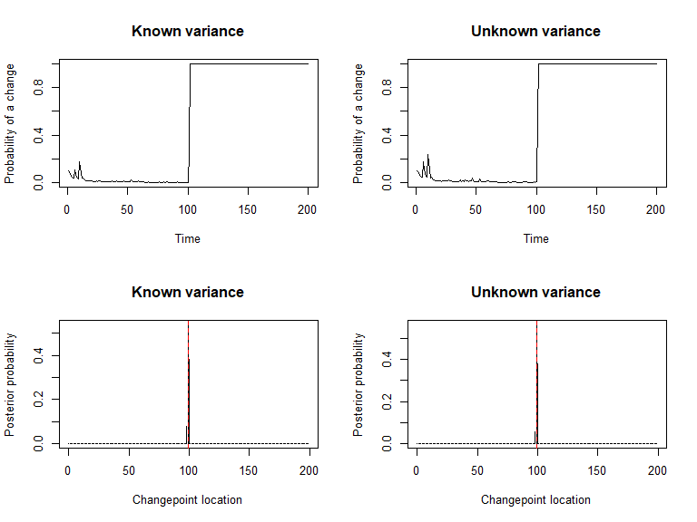

```r
map_slope_disc_kv <- changepoint(fit_slope_disc_kv)$location
map_slope_disc_uv <- changepoint(fit_slope_disc_uv)$location
stoppingtime_slope_disc_kv <- changepoint(fit_slope_disc_kv)$detected
stoppingtime_slope_disc_uv <- changepoint(fit_slope_disc_uv)$detected
par(mfrow = c(2, 2))

plot(1 - weights_tau_zero(fit_slope_disc_kv), type = "l", ylim = c(0, 1),
     xlab = "Time", ylab = "Probability of a change",
     main = "Known variance", col = "black")

plot(1 - weights_tau_zero(fit_slope_disc_uv), type = "l", ylim = c(0, 1),
     xlab = "Time", ylab = "Probability of a change",
     main = "Unknown variance", col = "black")

plot(seq_along(weights(fit_slope_disc_kv)) - 1, weights(fit_slope_disc_kv),
     type = "h", xlab = "Changepoint location",
     ylab = "Posterior probability", main = "Known variance", col = "black")
abline(v = map_slope_disc_kv, col = "red", lty = 2, lwd = 1.5)

plot(seq_along(weights(fit_slope_disc_uv)) - 1, weights(fit_slope_disc_uv),
     type = "h", xlab = "Changepoint location",
     ylab = "Posterior probability", main = "Unknown variance", col = "black")
abline(v = map_slope_disc_uv, col = "red", lty = 2, lwd = 1.5)
```

```r
group <- which.max(active_weights(fit_slope_disc_kv))
right <- taus(fit_slope_disc_kv)[group]
left <- right - length(ratios(fit_slope_disc_kv)[[group]]) + 1
print("Known variance: the most probable merged group is:")
[1] "Known variance: the most probable merged group is:"
print(c(left = left, right = right))
 left right
   99    99
print("They share the same estimated coefficients:")
[1] "They share the same estimated coefficients:"
print(active_posteriors(fit_slope_disc_kv)[[group]])
$tau
[1] 99

$weight
[1] 0.5387252

$mu
            [,1]
[1,]  0.00835908
[2,]  0.20002868
[3,] -1.16976836
[4,]  2.00225232

$sigma
              [,1]          [,2]          [,3]          [,4]
[1,]  0.0393131923 -5.912247e-04  1.902693e-02  5.940488e-04
[2,] -0.0005912247  1.191452e-05 -5.824608e-04 -1.200099e-05
[3,]  0.0190269345 -5.824608e-04  7.805034e-02 -6.990187e-09
[4,]  0.0005940488 -1.200099e-05 -6.990187e-09  2.364914e-05
group <- which.max(active_weights(fit_slope_disc_uv))
right <- taus(fit_slope_disc_uv)[group]
left <- right - length(ratios(fit_slope_disc_uv)[[group]]) + 1
print("Unknown variance: the most probable merged group is:")
[1] "Unknown variance: the most probable merged group is:"
print(c(left = left, right = right))
 left right
   99    99
print("They share the same estimated coefficients:")
[1] "They share the same estimated coefficients:"
print(active_posteriors(fit_slope_disc_uv)[[group]])
$tau
[1] 99

$weight
[1] 0.5647098

$mu
            [,1]
[1,]  0.00835908
[2,]  0.20002868
[3,] -1.16976836
[4,]  2.00225232

$sigma
              [,1]          [,2]          [,3]          [,4]
[1,]  0.0393131923 -5.912247e-04  1.902693e-02  5.940488e-04
[2,] -0.0005912247  1.191452e-05 -5.824608e-04 -1.200099e-05
[3,]  0.0190269345 -5.824608e-04  7.805034e-02 -6.990187e-09
[4,]  0.0005940488 -1.200099e-05 -6.990187e-09  2.364914e-05

$nu
[1] 103

$iota
[1] 86.6424
```

# Example - change in seasonality

Bagel can detect changes in seasonality or include seasonality as a background signal by adding Fourier basis functions to the linear model. Here we show how to detect a change in seasonality. Assuming a fixed period $P=24$ and one harmonic, the model can be written as

$$y_t=\beta_s s_t+\beta_c c_t+
(\gamma_s s_t+\gamma_c c_t)\mathbf{1}(t>\tau)+\varepsilon_t,$$
where $s_t=\sin(2\pi t/P)$ and $c_t=\cos(2\pi t/P)$.

Define the feature vector as
$$h_t(0)=\left[s_t,\,c_t\right]^{\mathsf T},\qquad
h_t(\tau)=\left[s_t,\,c_t,\,s_t\mathbf{1}(t>\tau),\,c_t\mathbf{1}(t>\tau)\right]^{\mathsf T}\quad(\tau\geq1),$$
and the prior and transformation functions as
$$\mu=\left[0,\,0,\,0,\,0\right]^{\mathsf T},\qquad D=4I_2,\qquad
\Sigma=\left[\begin{matrix}D&-D\\-D&2D\end{matrix}\right],\qquad
A_\tau=\left[\begin{matrix}I_2&I_2\end{matrix}\right].$$
We assume $\sigma_\varepsilon=1$ when known, or $\nu=3,\ \iota=2$ for the inverse-gamma prior when unknown.

```r
period <- 24

feature_seasonal <- function(t, tau) {
  basis <- c(sin(2 * pi * t / period), cos(2 * pi * t / period))
  if (tau == 0) return(matrix(basis, ncol = 1))
  matrix(c(basis, as.numeric(t > tau) * basis), ncol = 1)
}

prior_seasonal <- function(t) {
  D <- diag(c(4, 4))
  if (t == 1) return(list(mu = matrix(0, 2, 1), sigma = D))
  list(mu = matrix(0, 4, 1),
       sigma = rbind(cbind(D, -D), cbind(-D, 2 * D)))
}

transform_seasonal <- function(tau) {
  if (tau == 0) return(diag(2))
  cbind(diag(2), diag(2))
}

set.seed(0)
t_seasonal <- seq_len(n_obs)
seasonal_mean <- ifelse(t_seasonal <= tau_true,
                        sin(2 * pi * t_seasonal / period),
                        1.5 * cos(2 * pi * t_seasonal / period))
y_seasonal <- seasonal_mean + rnorm(length(t_seasonal), sd = 1)
```

```r
fit_seasonal_kv <- bagel_kv_approximate(
  Y = y_seasonal, feature_vector = feature_seasonal, prior = prior_seasonal,
  transform = transform_seasonal, p0 = 0.9, p = 1, sigma = 1,
  max_particles = 30, threshold = Inf
)

fit_seasonal_uv <- bagel_uv_approximate(
  Y = y_seasonal, feature_vector = feature_seasonal, prior = prior_seasonal,
  transform = transform_seasonal, p0 = 0.9, p = 1, nu = 3, iota = 2,
  max_particles = 30, threshold = Inf
)
```

We use the same syntax to fit the seasonal-change model and plot the results.

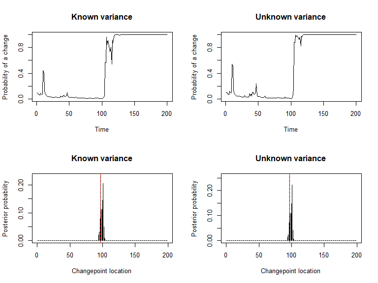

```r
map_seasonal_kv <- changepoint(fit_seasonal_kv)$location
map_seasonal_uv <- changepoint(fit_seasonal_uv)$location
par(mfrow = c(2, 2))

plot(1 - weights_tau_zero(fit_seasonal_kv), type = "l", ylim = c(0, 1),
     xlab = "Time", ylab = "Probability of a change",
     main = "Known variance", col = "black")

plot(1 - weights_tau_zero(fit_seasonal_uv), type = "l", ylim = c(0, 1),
     xlab = "Time", ylab = "Probability of a change",
     main = "Unknown variance", col = "black")

plot(seq_along(weights(fit_seasonal_kv)) - 1, weights(fit_seasonal_kv),
     type = "h", xlab = "Changepoint location",
     ylab = "Posterior probability", main = "Known variance", col = "black")
abline(v = map_seasonal_kv, col = "red", lty = 2, lwd = 1.5)

plot(seq_along(weights(fit_seasonal_uv)) - 1, weights(fit_seasonal_uv),
     type = "h", xlab = "Changepoint location",
     ylab = "Posterior probability", main = "Unknown variance", col = "black")
abline(v = map_seasonal_uv, col = "red", lty = 2, lwd = 1.5)
```

```r
group <- which.max(active_weights(fit_seasonal_kv))
right <- taus(fit_seasonal_kv)[group]
left <- right - length(ratios(fit_seasonal_kv)[[group]]) + 1
print("Known variance: the most probable merged group is:")
[1] "Known variance: the most probable merged group is:"
print(c(left = left, right = right))
 left right
   97    97
print("They share the same estimated coefficients:")
[1] "They share the same estimated coefficients:"
print(active_posteriors(fit_seasonal_kv)[[group]])
$tau
[1] 97

$weight
[1] 0.2322544

$mu
            [,1]
[1,]  1.04003514
[2,]  0.07208838
[3,] -1.08426924
[4,]  1.48891626

$sigma
             [,1]         [,2]          [,3]          [,4]
[1,]  0.020697199 -0.000105205 -0.0206971990  0.0001052050
[2,] -0.000105205  0.020332758  0.0001052050 -0.0203327581
[3,] -0.020697199  0.000105205  0.0394418117 -0.0004540495
[4,]  0.000105205 -0.020332758 -0.0004540495  0.0402858036
group <- which.max(active_weights(fit_seasonal_uv))
right <- taus(fit_seasonal_uv)[group]
left <- right - length(ratios(fit_seasonal_uv)[[group]]) + 1
print("Unknown variance: the most probable merged group is:")
[1] "Unknown variance: the most probable merged group is:"
print(c(left = left, right = right))
 left right
   97    97
print("They share the same estimated coefficients:")
[1] "They share the same estimated coefficients:"
print(active_posteriors(fit_seasonal_uv)[[group]])
$tau
[1] 97

$weight
[1] 0.256906

$mu
            [,1]
[1,]  1.04003514
[2,]  0.07208838
[3,] -1.08426924
[4,]  1.48891626

$sigma
             [,1]         [,2]          [,3]          [,4]
[1,]  0.020697199 -0.000105205 -0.0206971990  0.0001052050
[2,] -0.000105205  0.020332758  0.0001052050 -0.0203327581
[3,] -0.020697199  0.000105205  0.0394418117 -0.0004540495
[4,]  0.000105205 -0.020332758 -0.0004540495  0.0402858036

$nu
[1] 103

$iota
[1] 86.19156
```

# Example - change in mean with autocorrelated errors

The Bagel framework also accommodates autocorrelated errors through a suitable transformation. Here we consider a mean change with stationary AR(1) errors and a known autocorrelation coefficient $\rho=0.6$.

The model can be expressed as
$$y_t=\beta+\gamma\mathbf{1}(t>\tau)+e_t,\qquad
e_t=\rho e_{t-1}+\eta_t,\qquad
\eta_t\overset{\mathrm{iid}}\sim N(0,\sigma_\eta^2).$$

With $e_1\sim N(0,\sigma_\eta^2/(1-\rho^2))$, independent of subsequent innovations, we introduce the transformed observation $z_t=y_t-\rho y_{t-1}$ for $t\geq2$. Then
$$\begin{aligned}
z_t&=y_t-\rho y_{t-1}\\
&=(1-\rho)\beta+
\gamma\left[\mathbf{1}(t>\tau)-\rho\mathbf{1}(t-1>\tau)\right]+\eta_t,
\qquad t\geq2.
\end{aligned}$$
For the first observation, set $z_1=\sqrt{1-\rho^2}\,y_1$. The transformed errors are independent with variance $\sigma_\eta^2$.

Define the feature vector as
$$h_t(0)=\left[a_t\right],\qquad
h_t(\tau)=\left[a_t,\,\mathbf{1}(t>\tau)-\rho\mathbf{1}(t-1>\tau)\right]^{\mathsf T}\quad(\tau\geq1),$$
where
$$a_t=\begin{cases}\sqrt{1-\rho^2},&t=1,\\1-\rho,&t\geq2.\end{cases}$$
The prior and transformation are
$$\mu=\left[0,\,0\right]^{\mathsf T},\quad
\Sigma=\left[\begin{matrix}1&-1\\-1&2\end{matrix}\right],\quad
A_\tau=\left[\begin{matrix}1&1\end{matrix}\right].$$
We set $\sigma_\eta=0.7$ when the noise variance is known, or $\nu=3,\ \iota=2$ for the inverse-gamma prior on $\sigma_\eta^2$ when it is unknown. The coefficient covariance in this transformed model is $\sigma_\eta^2\Sigma$.

```r
rho <- 0.6

feature_ar1 <- function(t, tau) {
  baseline <- if (t == 1) sqrt(1 - rho^2) else 1 - rho
  if (tau == 0) return(matrix(baseline, 1, 1))
  change <- as.numeric(t > tau) - rho * as.numeric(t - 1 > tau)
  matrix(c(baseline, change), ncol = 1)
}

prior_ar1 <- function(t) {
  if (t == 1) {
    return(list(mu = matrix(0, 1, 1), sigma = matrix(1, 1, 1)))
  }
  list(mu = matrix(0, 2, 1), sigma = matrix(c(1, -1, -1, 2), 2, 2))
}

transform_ar1 <- function(tau) {
  if (tau == 0) return(matrix(1, 1, 1))
  matrix(c(1, 1), nrow = 1)
}

set.seed(0)
ar_error <- numeric(n_obs)
ar_error[1] <- rnorm(1, sd = 0.7 / sqrt(1 - rho^2))
for (t in 2:length(ar_error)) {
  ar_error[t] <- rho * ar_error[t - 1] + rnorm(1, sd = 0.7)
}
y_ar <- c(rep(0, tau_true), rep(2, n_obs - tau_true)) + ar_error
z_ar <- c(sqrt(1 - rho^2) * y_ar[1],
          y_ar[-1] - rho * head(y_ar, -1))
```

```r
fit_ar_kv <- bagel_kv_exact(
  Y = z_ar, feature_vector = feature_ar1, prior = prior_ar1,
  transform = transform_ar1, p0 = 0.9, p = 1, sigma = 0.7,
  max_particles = 30, threshold = Inf
)

fit_ar_uv <- bagel_uv_approximate(
  Y = z_ar, feature_vector = feature_ar1, prior = prior_ar1,
  transform = transform_ar1, p0 = 0.9, p = 1, nu = 3, iota = 2,
  max_particles = 30, threshold = Inf
)
```

We use the same syntax to fit the mean-change model with autocorrelated errors and plot the results.

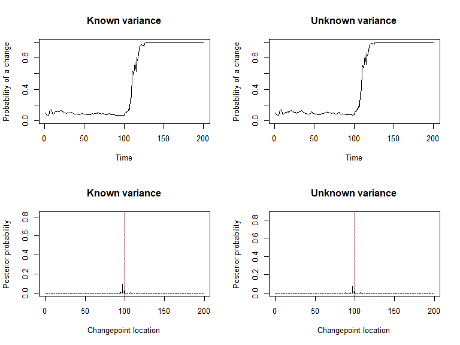

```r
map_ar_kv <- changepoint(fit_ar_kv)$location
map_ar_uv <- changepoint(fit_ar_uv)$location
par(mfrow = c(2, 2))

plot(1 - weights_tau_zero(fit_ar_kv), type = "l", ylim = c(0, 1),
     xlab = "Time", ylab = "Probability of a change",
     main = "Known variance", col = "black")

plot(1 - weights_tau_zero(fit_ar_uv), type = "l", ylim = c(0, 1),
     xlab = "Time", ylab = "Probability of a change",
     main = "Unknown variance", col = "black")

plot(seq_along(weights(fit_ar_kv)) - 1, weights(fit_ar_kv),
     type = "h", xlab = "Changepoint location",
     ylab = "Posterior probability", main = "Known variance", col = "black")
abline(v = map_ar_kv, col = "red", lty = 2, lwd = 1.5)

plot(seq_along(weights(fit_ar_uv)) - 1, weights(fit_ar_uv),
     type = "h", xlab = "Changepoint location",
     ylab = "Posterior probability", main = "Unknown variance", col = "black")
abline(v = map_ar_uv, col = "red", lty = 2, lwd = 1.5)
```

```r
group <- which.max(active_weights(fit_ar_kv))
right <- taus(fit_ar_kv)[group]
left <- right - length(ratios(fit_ar_kv)[[group]]) + 1
print("Known variance: the most probable merged group is:")
[1] "Known variance: the most probable merged group is:"
print(c(left = left, right = right))
 left right
  100   100
print("They share the same estimated coefficients:")
[1] "They share the same estimated coefficients:"
print(active_posteriors(fit_ar_kv)[[group]])
$tau
[1] 100

$weight
[1] 0.8219653

$mu
           [,1]
[1,] 0.03147318
[2,] 1.80439123

$sigma
            [,1]        [,2]
[1,]  0.05611729 -0.05422993
[2,] -0.05422993  0.10845987
group <- which.max(active_weights(fit_ar_uv))
right <- taus(fit_ar_uv)[group]
left <- right - length(ratios(fit_ar_uv)[[group]]) + 1
print("Unknown variance: the most probable merged group is:")
[1] "Unknown variance: the most probable merged group is:"
print(c(left = left, right = right))
 left right
  100   100
print("They share the same estimated coefficients:")
[1] "They share the same estimated coefficients:"
print(active_posteriors(fit_ar_uv)[[group]])
$tau
[1] 100

$weight
[1] 0.8580452

$mu
           [,1]
[1,] 0.03147318
[2,] 1.80439123

$sigma
            [,1]        [,2]
[1,]  0.05611729 -0.05422993
[2,] -0.05422993  0.10845987

$nu
[1] 103

$iota
[1] 45.3173
```

# Online detection - a mean-change example

We have shown how to apply Bagel offline. In practice, we may want to detect a change online. The following code shows how to use Bagel for online mean-change detection with a `for` loop. `update()` modifies the detector in place and returns the current no-change probability. The loop stops when the probability of a change exceeds the threshold, set to 0.95 in this example. The threshold should be calibrated through simulation or validation to achieve a target false alarm rate or average run length under no change. An `NA` alarm time means the threshold was not crossed; the MAP location is conditional on a change, excluding the first weight for no change.

The `change_tracer()` function records the change probability after each update. It receives the accumulated history and the current detector, and returns the updated history. We call it explicitly in the sequential loop because `update()` does not invoke a tracer automatically.

```r
change_tracer <- function(trace, bagel_object) {
  c(trace, 1 - weights_tau_zero(bagel_object))
}

online_mean <- sequential_bagel_kv_exact(
  feature_vector = feature_mean, prior = prior_mean,
  transform = transform_mean, p0 = 0.9, p = 1, sigma = 1,
  max_particles = 30
)

threshold <- 0.95
alarm_time <- NA_integer_
online_change_trace <- numeric(0)
for (y in y_mean) {
  w0 <- bagelR::update(online_mean, y)
  online_change_trace <- change_tracer(online_change_trace, online_mean)
  if (1 - w0 > threshold) {
    alarm_time <- bagelR::time(online_mean)
    break
  }
}

map_online_mean <- which.max(weights(online_mean)[-1])
print(c(alarm_time = alarm_time, MAP_location = map_online_mean))
  alarm_time MAP_location
         127           97
```

The figure below shows the online detection results. The first plot shows the probability of a change over time. The second shows the posterior distribution of the changepoint location given the data up to the alarm time, or the end of the stream if no alarm occurs.

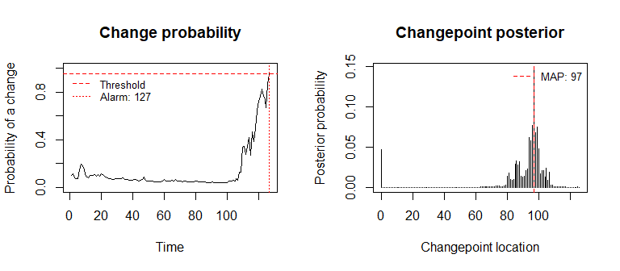

```r
par(mfrow = c(1, 2))

plot(online_change_trace, type = "l", ylim = c(0, 1),
     xlab = "Time", ylab = "Probability of a change",
     main = "Change probability", col = "black")
abline(h = threshold, col = "red", lty = 2)
if (!is.na(alarm_time)) abline(v = alarm_time, col = "red", lty = 3)
legend("topleft", legend = c("Threshold", paste("Alarm:", alarm_time)),
       col = "red", lty = c(2, 3), bty = "n", cex = 0.8, inset = c(0, 0.06))

online_posterior <- weights(online_mean)
plot(seq_along(online_posterior) - 1, online_posterior, type = "h",
     xlab = "Changepoint location", ylab = "Posterior probability",
     main = "Changepoint posterior", col = "black")
abline(v = map_online_mean, col = "red", lty = 2, lwd = 1.5)
legend("topright", legend = paste("MAP:", map_online_mean),
       col = "red", lty = 2, bty = "n", cex = 0.8)
```

# Multiple sequential detectors

Bagel also allows us to run multiple sequential detectors alongside one another on the same stream. This is useful when a change could be of different types.

Suppose we want to detect a continuous or discontinuous slope change. At each update, we consider three models: no change, continuous change, and discontinuous change.

We use the same model parameters as in the examples above and assign prior probabilities of 0.9, 0.05, and 0.05 to no change, continuous change, and discontinuous change, respectively.

After each update, we combine the results of two detectors to obtain probabilities for no change, a continuous change, and a discontinuous change. Both detectors use the same no-change model, so we include it only once when combining their results.

```r
p0_sub <- 0.9 / (0.9 + 0.05)
detectors <- list(
  continuous = sequential_bagel_kv_approximate(
    feature_slope_cont, prior_slope_cont, transform_slope_cont,
    p0 = p0_sub, p = 1, sigma = 1, max_particles = 30),
  discontinuous = sequential_bagel_kv_approximate(
    feature_slope_disc, prior_slope_disc, transform_slope_disc,
    p0 = p0_sub, p = 1, sigma = 1, max_particles = 30)
)

threshold <- 0.95
joint_alarm <- NA_integer_
joint_change_trace <- numeric(0)
for (y in y_slope_cont) {
  w0 <- vapply(detectors, function(model) bagelR::update(model, y), numeric(1))
  model_probability <- c(no_change = 1, (1 - w0) / w0)
  model_probability <- model_probability / sum(model_probability)
  joint_change_trace <- c(joint_change_trace, sum(model_probability[-1]))
  if (sum(model_probability[-1]) > threshold) {
    joint_alarm <- bagelR::time(detectors$continuous)
    break
  }
}
print(c(alarm_time = joint_alarm, model_probability))
   alarm_time     no_change    continuous discontinuous
 1.030000e+02  5.755139e-06  5.994825e-01  4.005117e-01
```

To determine whether a change has occurred, we sum the probabilities of continuous and discontinuous changes. To assess the type of change, we compare the posterior probabilities of the two change models.

Here, we show the change-probability trace and the changepoint-location posterior after summing over both types of change.

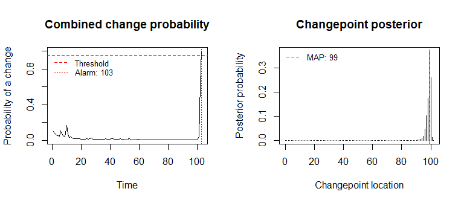

```r
post_cont <- weights(detectors$continuous)
post_disc <- weights(detectors$discontinuous)
joint_posterior <- c(1, post_cont[-1] / post_cont[1] + post_disc[-1] / post_disc[1])
joint_posterior <- joint_posterior / sum(joint_posterior)
map_joint <- which.max(joint_posterior[-1])

par(mfrow = c(1, 2))

plot(joint_change_trace, type = "l", ylim = c(0, 1),
     xlab = "Time", ylab = "Probability of a change",
     main = "Combined change probability", col = "black")
abline(h = threshold, col = "red", lty = 2)
abline(v = joint_alarm, col = "red", lty = 3)
legend("topleft", legend = c("Threshold", paste("Alarm:", joint_alarm)),
       col = "red", lty = c(2, 3), bty = "n", cex = 0.8, inset = c(0, 0.06))

plot(seq_along(joint_posterior) - 1, joint_posterior, type = "h",
     xlab = "Changepoint location", ylab = "Posterior probability",
     main = "Changepoint posterior", col = "black")
abline(v = map_joint, col = "red", lty = 2, lwd = 1.5)
legend("topleft", legend = paste("MAP:", map_joint),
       col = "red", lty = 2, bty = "n", cex = 0.8)
```

# References

The algorithm is described in [*Yang, Z., Fearnhead, P., and Grose, D. (2026). Bagel: A Fast Bayesian Online Changepoint Detection Algorithm for Linear Models via Posterior Merging*](https://arxiv.org/abs/2611.03230v1).

The Azure dataset is described in the paper by Jovan Stojkovic, Chaojie Zhang, Íñigo Goiri, Josep Torrellas, and Esha Choukse, [*DynamoLLM: Designing LLM Inference Clusters for Performance and Energy Efficiency*](https://arxiv.org/abs/2408.00741), in Proceedings of the International Symposium on High-Performance Computer Architecture (HPCA 2025). IEEE, Las Vegas, USA, 2025., and can be accessed directly from [Azure LLM inference trace 2024](https://github.com/Azure/AzurePublicDataset/blob/master/AzureLLMInferenceDataset2024.md). For the video, we averaged the generated tokens per code request over five-minute intervals. The analysis is described in [our paper](https://arxiv.org/abs/2611.03230v1).

The synthetic speech in the video was generated with [Kokoro v1.0](https://huggingface.co/hexgrad/Kokoro-82M), voice `bf_alice` (model weights licensed under Apache 2.0).

# AI disclosure

GPT-6 Astra Extra high was used to generate the video based on the author’s instructions and to check the grammar of this document.